# 언어학과심리실험

### 기말고사 대체과제 중간 보고서

#### 201801285 컴퓨터전자지스템공학과 김희찬

- 총 19개의 테스트 데이터셋에서 ‘231203 김강현.csv’ 파일을 제외한 모든 데이터를 대상으로 합니다. (인코딩 문제)
- 새로 저장할 파일에는 ‘who’, ‘correctness’, ‘correct_response’, ‘response_target’, ‘response_time’, ‘relation’, ‘prime’, ‘prime_condition’, ‘target’, ‘target_condition’ 이라는 컬럼들을 포함시킵니다.
- ‘who’ 컬럼은 각 데이터가 원래 저장되어 있던 엑셀 파일의 이름을 나타내며, ‘correctness’ 컬럼은 ’correct_response’와 ’response_target’이 일치하는 경우 1로, 불일치하는 경우 0으로 표시됩니다.

### 필터링되어 취합된 데이터 읽기

### relation 기준으로 한 정답률, 반응시간

| relation | correctness | response_time |
| --- | --- | --- |
| inclusive | 0.948 | 0.027 |
| no-correlation | 0.956 | 0.026 |
| non-word | 0.898 | 0.024 |
| same phoneme | 0.889 | 0.026 |
| similar-environmental | 0.915 | 0.026 |

### relation 기준으로 한 정답률, 반응시간의 One-way ANOVA

```
##               Df Sum Sq Mean Sq F value   Pr(>F)
## relation       4   1.47  0.3679   5.109 0.000428 ***
## Residuals   1975 142.24  0.0720
## ---
## Signif. codes:  0 '***' 0.001 '**' 0.01 '*' 0.05 '.' 0.1 ' ' 1
```

```
##               Df Sum Sq   Mean Sq F value Pr(>F)
## relation       4 0.0008 0.0001908   0.888   0.47
## Residuals   1975 0.4244 0.0002149
```

- relation은 정답률에는 유의미한 영향을 미치고, response_time에는 그렇지 못함.

### prime과 target의 condition을 기준으로 한 정답률, 반응시간

| relation | prime_condition | target_condition | correctness | response_time |
| --- | --- | --- | --- | --- |
| inclusive | artifactual | artifactual | 0.92857 | 0.02641 |
| no-correlation | artifactual | artifactual | 0.95238 | 0.02535 |
| same phoneme | artifactual | artifactual | 0.95238 | 0.02498 |
| similar-environmental | artifactual | artifactual | 0.92063 | 0.02440 |
| no-correlation | natural | artifactual | 0.91270 | 0.02632 |
| same phoneme | natural | artifactual | 0.86508 | 0.02905 |
| similar-environmental | natural | artifactual | 0.83333 | 0.02599 |
| non-word | non-word | artifactual | 0.96296 | 0.02533 |
| no-correlation | artifactual | natural | 0.98413 | 0.02553 |
| same phoneme | artifactual | natural | 0.81746 | 0.02505 |
| similar-environmental | artifactual | natural | 0.95238 | 0.02741 |
| inclusive | natural | natural | 0.96825 | 0.02684 |
| no-correlation | natural | natural | 0.97619 | 0.02569 |
| same phoneme | natural | natural | 0.92063 | 0.02560 |
| similar-environmental | natural | natural | 0.95238 | 0.02559 |
| non-word | non-word | natural | 1.00000 | 0.02433 |
| non-word | artifactual | non-word | 0.83333 | 0.02316 |
| non-word | natural | non-word | 0.79630 | 0.02419 |

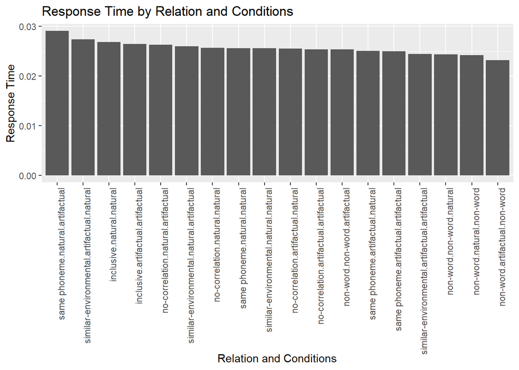

### prime과 target의 condition을 기준으로 한 정답률, 반응시간의 Two-way ANOVA

```
##                                  Df   Sum Sq  Mean Sq F value Pr(>F)
## prime_condition                   2 0.009833 0.004917   2.290 0.1518
## target_condition                  2 0.025101 0.012550   5.846 0.0208 *
## prime_condition:target_condition  3 0.009566 0.003189   1.485 0.2774
## Residuals                        10 0.021468 0.002147
## ---
## Signif. codes:  0 '***' 0.001 '**' 0.01 '*' 0.05 '.' 0.1 ' ' 1
```

```
##                                  Df    Sum Sq   Mean Sq F value Pr(>F)
## prime_condition                   2 4.456e-06 2.228e-06   1.850 0.2073
## target_condition                  2 1.006e-05 5.029e-06   4.175 0.0481 *
## prime_condition:target_condition  3 3.366e-06 1.122e-06   0.931 0.4610
## Residuals                        10 1.205e-05 1.204e-06
## ---
## Signif. codes:  0 '***' 0.001 '**' 0.01 '*' 0.05 '.' 0.1 ' ' 1
```

- target_condition은 정답률과 response_time에 통계적으로 유의미한 영향을 미침.
- prime_condition과 prime_condition과 target_condition의 상호작용은 정답률과 response_time에 유의미한 영향을 미치지 않음.
- 즉, target_condition에 따라 correctness와 response_time은 통계적으로 유의미하게 달라지지만, prime_condition과 prime_condition과 target_condition의 상호작용은 그렇지 않음.

### relation 및 prime과 target의 condition을 기준으로 한 정답률, 반응시간의 Three-way ANOVA

```
##                                             Df Sum Sq Mean Sq F value   Pr(>F)
## relation                                     4   1.47  0.3679   5.245 0.000335
## prime_condition                              2   1.58  0.7885  11.240  1.4e-05
## target_condition                             1   0.48  0.4772   6.802 0.009173
## relation:prime_condition                     4   0.23  0.0570   0.813 0.516693
## relation:target_condition                    3   0.91  0.3036   4.328 0.004755
## prime_condition:target_condition             1   1.01  1.0060  14.341 0.000157
## relation:prime_condition:target_condition    2   0.41  0.2044   2.913 0.054528
## Residuals                                 1962 137.63  0.0701
##
## relation                                  ***
## prime_condition                           ***
## target_condition                          **
## relation:prime_condition
## relation:target_condition                 **
## prime_condition:target_condition          ***
## relation:prime_condition:target_condition .
## Residuals
## ---
## Signif. codes:  0 '***' 0.001 '**' 0.01 '*' 0.05 '.' 0.1 ' ' 1
```

```
##                                             Df Sum Sq   Mean Sq F value Pr(>F)
## relation                                     4 0.0008 0.0001908   0.887  0.471
## prime_condition                              2 0.0004 0.0002090   0.971  0.379
## target_condition                             1 0.0000 0.0000376   0.175  0.676
## relation:prime_condition                     4 0.0004 0.0000991   0.460  0.765
## relation:target_condition                    3 0.0006 0.0001945   0.904  0.438
## prime_condition:target_condition             1 0.0006 0.0006309   2.932  0.087
## relation:prime_condition:target_condition    2 0.0001 0.0000746   0.347  0.707
## Residuals                                 1962 0.4222 0.0002152
##
## relation
## prime_condition
## target_condition
## relation:prime_condition
## relation:target_condition
## prime_condition:target_condition          .
## relation:prime_condition:target_condition
## Residuals
## ---
## Signif. codes:  0 '***' 0.001 '**' 0.01 '*' 0.05 '.' 0.1 ' ' 1
```

- relation, prime_condition, 그리고 target_condition은 정답률에 통계적으로 유의미한 영향을 미침
- relation과 prime_condition의 상호작용은 정답률에 통계적으로 유의미한 영향을 미치지 않음.
- relation과 target_condition의 상호작용은 정답률에 통계적으로 유의미한 영향을 미침.
- prime_condition과 target_condition의 상호작용은 정답률에 통계적으로 유의미한 영향을 미침.
- relation, prime_condition, target_condition의 세 가지 변수의 상호작용은 정답률에 통계적으로 유의미한 영향을 미치지 않음.
- 모든 변수와 상호작용 효과는 response_time에 통계적으로 유의미한 영향을 미치지 않음.

### aritifactual condition이 포함된 경우를 기준으로 한 정답률, 반응시간

| relation | prime_condition | target_condition | correctness | response_time |
| --- | --- | --- | --- | --- |
| inclusive | artifactual | artifactual | 0.92857 | 0.02641 |
| no-correlation | artifactual | artifactual | 0.95238 | 0.02535 |
| same phoneme | artifactual | artifactual | 0.95238 | 0.02498 |
| similar-environmental | artifactual | artifactual | 0.92063 | 0.02440 |
| no-correlation | natural | artifactual | 0.91270 | 0.02632 |
| same phoneme | natural | artifactual | 0.86508 | 0.02905 |
| similar-environmental | natural | artifactual | 0.83333 | 0.02599 |
| non-word | non-word | artifactual | 0.96296 | 0.02533 |
| no-correlation | artifactual | natural | 0.98413 | 0.02553 |
| same phoneme | artifactual | natural | 0.81746 | 0.02505 |
| similar-environmental | artifactual | natural | 0.95238 | 0.02741 |
| non-word | artifactual | non-word | 0.83333 | 0.02316 |

```
##   correctness response_time
##    0.90961199    0.02574938
```

### natural condition이 포함된 경우를 기준으로 한 정답률, 반응시간

| relation | prime_condition | target_condition | correctness | response_time |
| --- | --- | --- | --- | --- |
| no-correlation | natural | artifactual | 0.91270 | 0.02632 |
| same phoneme | natural | artifactual | 0.86508 | 0.02905 |
| similar-environmental | natural | artifactual | 0.83333 | 0.02599 |
| no-correlation | artifactual | natural | 0.98413 | 0.02553 |
| same phoneme | artifactual | natural | 0.81746 | 0.02505 |
| similar-environmental | artifactual | natural | 0.95238 | 0.02741 |
| inclusive | natural | natural | 0.96825 | 0.02684 |
| no-correlation | natural | natural | 0.97619 | 0.02569 |
| same phoneme | natural | natural | 0.92063 | 0.02560 |
| similar-environmental | natural | natural | 0.95238 | 0.02559 |
| non-word | non-word | natural | 1.00000 | 0.02433 |
| non-word | natural | non-word | 0.79630 | 0.02419 |

```
##   correctness response_time
##    0.91490300    0.02596645
```

### aritifactual/natural condition이 포함된 경우를 기준으로 한 정답률, 반응시간의 독립표본 t-검정

```
##
##  Welch Two Sample t-test
##
## data:  artifactual_summary$correctness and natural_summary$correctness
## t = -0.20188, df = 21.193, p-value = 0.8419
## alternative hypothesis: true difference in means is not equal to 0
## 95 percent confidence interval:
##  -0.05976477  0.04918276
## sample estimates:
## mean of x mean of y
##  0.909612  0.914903
```

```
##
##  Welch Two Sample t-test
##
## data:  artifactual_summary$response_time and natural_summary$response_time
## t = -0.37491, df = 21.746, p-value = 0.7114
## alternative hypothesis: true difference in means is not equal to 0
## 95 percent confidence interval:
##  -0.0014186143  0.0009844851
## sample estimates:
##  mean of x  mean of y
## 0.02574938 0.02596645
```

- p-value가 각각 0.8419, 0.7114로 유의미한 차이를 보이지 않음.